# What Democratic Socialism means to me

2018-01-02

> Note: My local chapter of the Democratic Socialists of America opens every monthly meeting with a member sharing their story of what Democratic Socialism means to them. At the January 2018 meeting, I got to tell mine. The following is what I read.

In the late 1800’s, a young man named Adolphe was looking for work in his hometown of Lévis, across the river from Québec City. The economy in that area in that time wasn’t particularly favorable. To find work, he resorted to what many of his fellow French Canadians did, and followed the railroad tracks into New England to work in the burgeoning manufacturing industries.

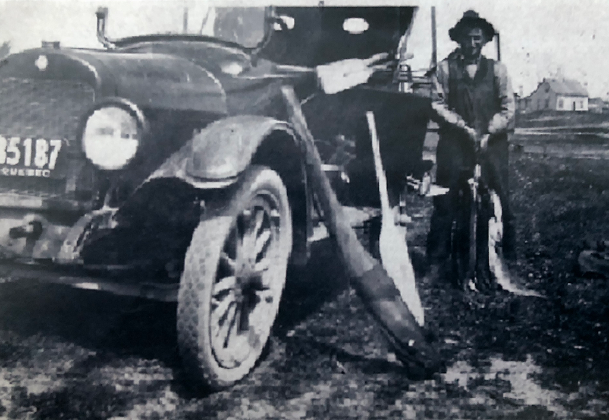

Adolpe Desjardins — Sorry about the blurry photo

Adolphe ended up working in several different factories and mills, and eventually ended up at a paper mill owned by 19th century industrialist, Hugh Chisolm. Chisolm had built a small army of paper mills in the northeastern United States, and would eventually go on to co-found International Paper Co.

In the summer of 1942, at 60 years old, Adolphe was scheduled to take his very first vacation. At that point, he was working as an assistant to the mill manager — in those days, this was called a “retirement job” because the back-breaking work of papermaking gets to be pretty difficult after forty years. He went down to the basement of the mill where trucks would unload materials for the mill. While he was there, Adolphe was accidentally hit by one of the trucks.

Things did not look good for Adolphe, so they called the local priest to administer last rights (it was, after all, a Catholic town). The priest couldn’t drive, so one of the priest’s young assistants drove him down to the mill for the somber ritual. When they arrived, to his horror, the assistant said “this man is my father.”

That assistant was my grandfather, Clement Desjardins. After serving our country stateside in World War II (his two older brothers were already overseas), he came home and married his sweetheart, Lucille. During those days in Jay, the Irish worked in the shoe shops, the Italians worked in the quarry, so my grandfather fulfilled his fate and did what all the French Canadians in Jay did; he went to work in the mill — the same mill that killed his father.

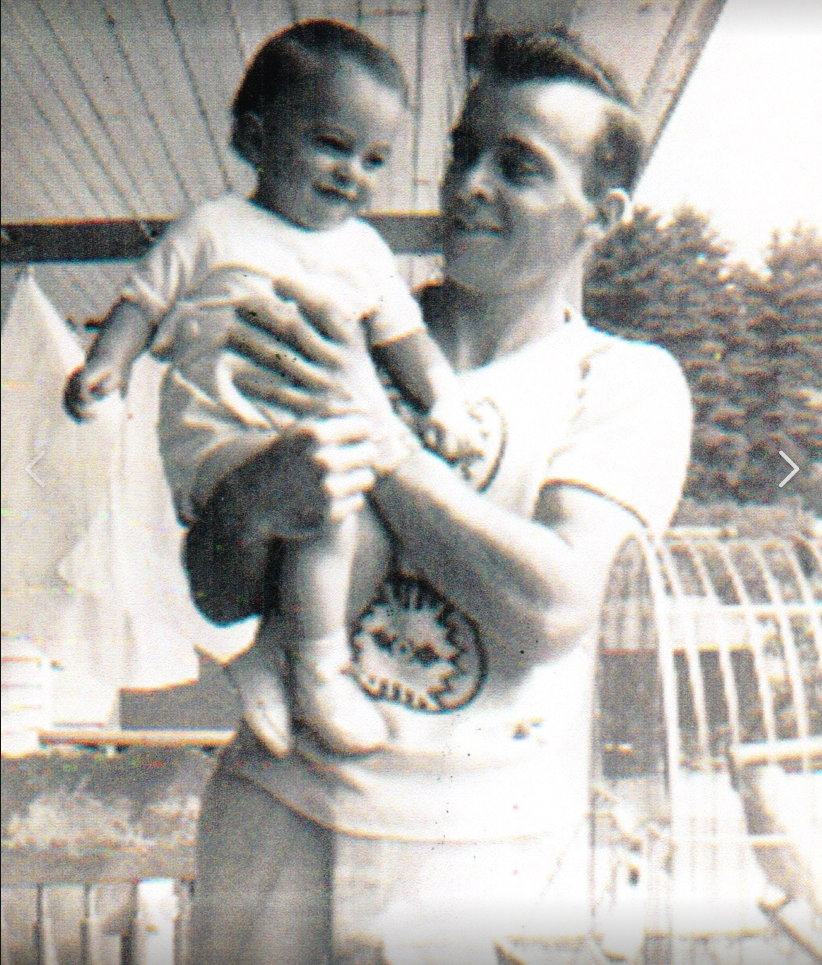

My dad, Dennis, with his father Clement Desjardins

While my dad worked shift-work and the occasional sixteen hour shift, my mother attended night school at the University of Maine at Farmington, and eventually became a public school teacher. I’m sure it wasn’t easy for them, especially given that I wasn’t the easiest kid to raise. Today I’d probably get treatment for ADHD, but back then I was just a pain in the ass.

In 1987, I was 12 years old. Ronald Reagan was President. The prevailing wisdom was that labor unions were an anachronistic weight on our economy, and President Reagan demonstrated how to deal with them when he summarily fired the all of the nation’s air traffic controllers five years prior. The union’s contract at International Paper’s Androscoggin Mill was up for renegotiation. After boasting literally record profits, the company demanded eye-popping concessions from the union. There was never any intention to negotiate, it was a bald-faced attempt to break the union.

The strike started in June. Every night our town was featured on the six o’clock news, interrupted by public relations commercials from International Paper, telling “their side of the story,” and how great the greedy union workers had things.

Often the news was an update on the farcical negotiations, but sometimes it got more interesting; one time a “scab” claimed his house was shot at (if I remember correctly, it was later determined that he shot at his own home). Another story was about a high school protest and walk-out by the union kids, upset that they couldn’t wear strike-related clothing while their scab-kid counterparts wore clothes with International Paper logos. One of the biggest stories was when Jesse Jackson came to town to give a presidential campaign speech in the municipal building — Mr. Jackson was the first presidential candidate I heard speak while the crowd chanted “scabs out, union in!”

(For those who are unfamiliar with strike parlance — a “scab” is someone who crosses the picket line and returns to work. A “super scab” is a former union member who goes back to work)

Let me tell you, you don’t grow up in your formative years in that environment, and come out of it a capitalist.

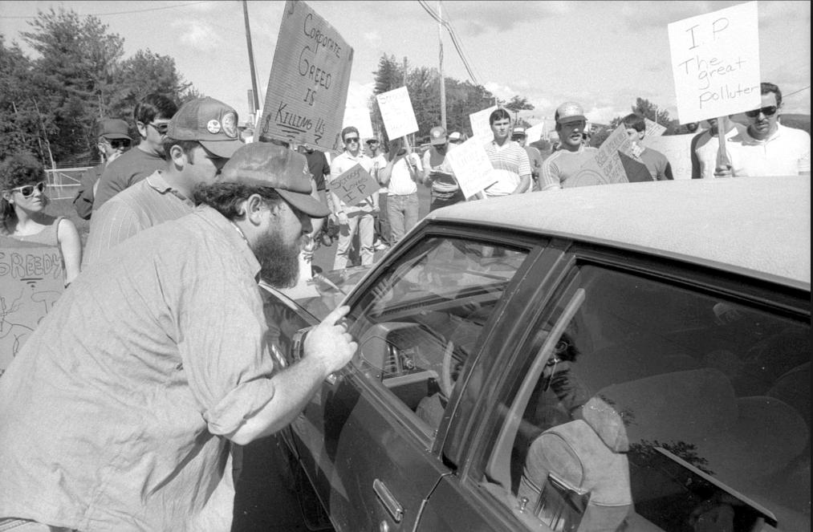

Picketers from UPIU Local 14 during the Androscoggin Mill strike

The strike technically ended, a little over a year later. The union had effectively lost. The United Paperworkers International Union’s support for the locals who were fighting International Paper became tepid. But after the strike, the town of Jay wasn’t quite the same. Union members were hired back by attrition, and it took many years for them to be called back — many reached retirement age before getting their call. International Paper sold the mill to a private equity firm about ten years ago, and the machines that have not been shuttered are run by non-union workers.

I went to an engineering college in Massachusetts, but settled back in Maine to raise a family. My job today is cushy. I work in at home, in my pajamas, writing software. I am paid well, probably more than I deserve. My job doesn’t make me sweat, or make my muscles sore in the morning, or require me to work weird shifts. I don’t worry about my safety. A lot of that is because my parents made damned sure I stayed the hell away from that paper mill.

I think there are two things that have drawn me to democratic socialism. The first is a steadfast refusal to accept economic injustice and inequality. This is a personal passion that was ignited within me when I grew up during the strike. I had a front row seat to watching corporate greed hollow out the working class. I saw International Paper spend millions of dollars on phony security systems, television ads, and public relations firms, all money that could’ve gone to their dedicated employees instead. It was all to prove a point: Capital controls labor — Know your place. I saw that the wealthy’s appetite for more wealth knows no boundaries.

The second thing that draws me to democratic socialism is a strange, almost spiritual connection with the generations who came before me — at the risk of sounding corny, these meetings are my church and the “beer caucuses” afterward my communion.

In a sense, I’ve made it. I am of the bourgeoisie. But if I’m honest with myself, I’ve done relatively little to earn that. My parents helped save and prepare me for college so that I’d have a better life. My grandfather raised a family of six in the house that he built himself with his mill salary, and my great grandfather literally gave his life to the paper making industry. My maternal family line also contributed to my progressive worldview—in fact, my mother’s grandfather was also killed in a papermill.

I owe it to those generations before me to help the disadvantaged, and take direct action toward a world that is more equitable and just. There are lots of ways to taxonomize what “kind” of socialist you are, and there will always be some people who will pass judgement on who is or is not a “real” socialist. But in the end I feel like we, in this meeting, are all really seeking fairness . Regardless of whether you’re a “tankie”, Trotskyist, or a mere shell-shocked Social Democrat with nowhere else to go, it doesn’t matter how or why you want to seize the means of production. What matters is preventing the greediest among us from hoarding the means of production, and using it as a cudgel to dominate and control the rest of us.

I’m thrilled that since joining the DSA I’ve been able to march in a Pride parade, phone bank for Ranked Choice Voting, drop literature for a rent stabilization initiative, and gain a sense of solidarity with other like-minded people. Without the DSA, I probably wouldn’t have done any of those things. Without the DSA, my so-called “activism” probably would’ve been confined to reposting memes on social media. Democratic Socialism gives me a sense of purpose, and helps me identify ways to help on my “justice mission.” And for that, I’m thankful.

[This work is licensed under a [Creative Commons Attribution-NonCommercial-NoDerivatives 4.0 International License](http://creativecommons.org/licenses/by-nc-nd/4.0/) .](http://creativecommons.org/licenses/by-nc-nd/4.0/)